# Script_Operation

# Vérification de la présence de valeurs manquantes

```r
# Valeurs manquantes par colonne
colSums(is.na(data))
```

```
##                    ID                 ANNEE             COMMU_LAB
##                     0                     0                   298
##                  RAIN            Sol_simple              type_sol
##                     0                    74                  2609
##      Date_prelevement   Date_enregistrement          Date_analyse
##                     0                     0                     0
##        Operateur_chld      Taux_Chlordecone          Operateur_5b
##                     0                     0                     0
##         Taux_5b_hydro histoBanane_Histo_ban          mnt_tpi_mean
##                    23                 17983                    28
##          mnt_tri_mean     mnt_rugosite_mean      mnt_ombrage_mean
##                    28                    28                    28
##   mnt_exposition_mean        mnt_pente_mean                     X
##                    28                    28                     0
##                     Y
##                     0
```

Suite à ces résultats, on décide pour la suite des analyses, d’imputer par la moyenne les variables quantitatives.

```r
vars_num <- c("mnt_tpi_mean", "mnt_tri_mean", "mnt_rugosite_mean",
              "mnt_ombrage_mean", "mnt_exposition_mean", "mnt_pente_mean")

for (v in vars_num) {
  data[[v]][is.na(data[[v]])] <- mean(data[[v]], na.rm = TRUE)
}
```

```r
# Vérification après imputation
colSums(is.na(data))
```

```
##                    ID                 ANNEE             COMMU_LAB
##                     0                     0                   298
##                  RAIN            Sol_simple              type_sol
##                     0                    74                  2609
##      Date_prelevement   Date_enregistrement          Date_analyse
##                     0                     0                     0
##        Operateur_chld      Taux_Chlordecone          Operateur_5b
##                     0                     0                     0
##         Taux_5b_hydro histoBanane_Histo_ban          mnt_tpi_mean
##                    23                 17983                     0
##          mnt_tri_mean     mnt_rugosite_mean      mnt_ombrage_mean
##                     0                     0                     0
##   mnt_exposition_mean        mnt_pente_mean                     X
##                     0                     0                     0
##                     Y
##                     0
```

```r
data$COMMU_LAB[is.na(data$COMMU_LAB)] <- "Inconnu"
data$Sol_simple[is.na(data$Sol_simple)] <- "Inconnu"
data$type_sol[is.na(data$type_sol)] <- "Inconnu"
```

Les variables quantitatives présentant peu de valeurs manquantes ont été imputées par la moyenne afin de conserver l’information statistique. Les variables qualitatives ont été recodées en une modalité “Inconnu”. Une variable présentant un taux de valeurs manquantes trop élevé (>50%) a été mise de côté afin d’éviter un biais dans les analyses.

# Analyse exploratoire des données

Quels facteurs expliquent la contamination au chlordécone ?

On va tester :

-Sol - Pluie - Commune - Variables topographiques - Temps (année) - 5b-hydro

## Statistiques descriptives du chlordécone

```r
summary(data$Taux_Chlordecone)
```

```
##    Min. 1st Qu.  Median    Mean 3rd Qu.    Max.
##  0.0010  0.0024  0.0033  0.6677  0.4100 17.3500
```

```r
sd(data$Taux_Chlordecone, na.rm = TRUE)
```

```
## [1] 1.559895
```

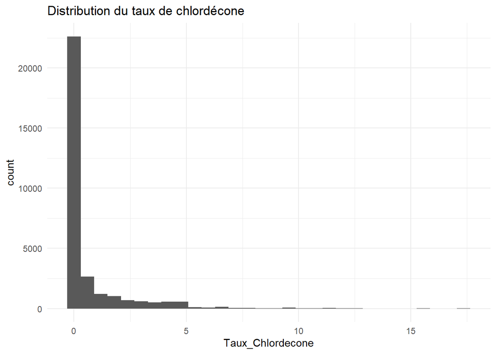

```r
# Histogramme
ggplot(data, aes(x = Taux_Chlordecone)) +
  geom_histogram(bins = 30) +
  theme_minimal() +
  labs(title = "Distribution du taux de chlordécone")
```

La distribution du taux de chlordécone est asymétrique à droite, indiquant que la majorité des parcelles présentent une faible contamination tandis que certaines parcelles présentent des niveaux très élevés.

## Effet du type de sol

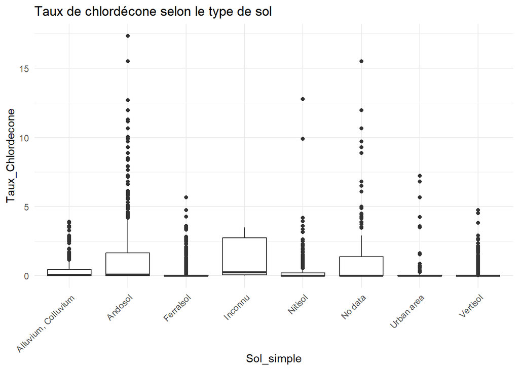

```r
ggplot(data, aes(x = Sol_simple, y = Taux_Chlordecone)) +
  geom_boxplot() +
  theme_minimal() +
  theme(axis.text.x = element_text(angle = 45, hjust = 1)) +
  labs(title = "Taux de chlordécone selon le type de sol")
```

```r
anova_sol <- aov(Taux_Chlordecone ~ Sol_simple, data = data)
summary(anova_sol)
```

```
##                Df Sum Sq Mean Sq F value Pr(>F)
## Sol_simple      7   7670  1095.7   500.9 <2e-16 ***
## Residuals   31118  68066     2.2
## ---
## Signif. codes:  0 '***' 0.001 '**' 0.01 '*' 0.05 '.' 0.1 ' ' 1
```

La p-value < 0.05, on conclut que le type de sol influence significativement la contamination.

A l’aide du graphique, on peut déjà se faire une idée des sols potentiellement influant sur le taux de chlordecone come par exemple le ‘Andosol’.

## Effet de la pluviométrie

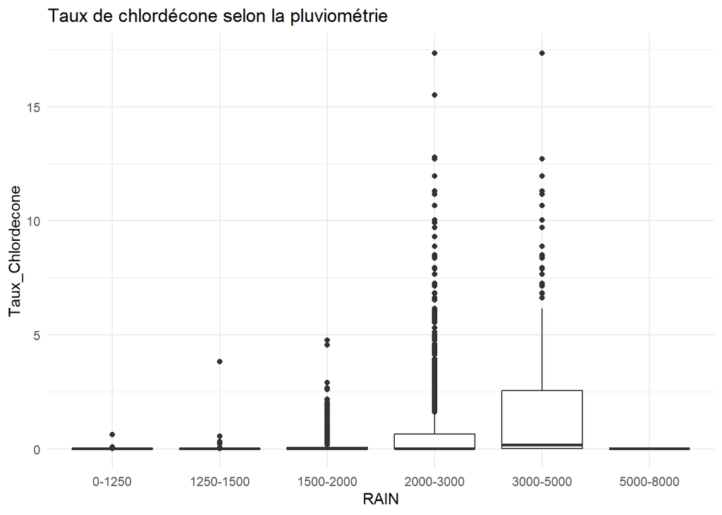

```r
ggplot(data, aes(x = RAIN, y = Taux_Chlordecone)) +
  geom_boxplot() +
  theme_minimal() +
  labs(title = "Taux de chlordécone selon la pluviométrie")
```

```r
anova_rain <- aov(Taux_Chlordecone ~ RAIN, data = data)
summary(anova_rain)
```

```
##                Df Sum Sq Mean Sq F value Pr(>F)
## RAIN            5   5500  1099.9   487.3 <2e-16 ***
## Residuals   31120  70236     2.3
## ---
## Signif. codes:  0 '***' 0.001 '**' 0.01 '*' 0.05 '.' 0.1 ' ' 1
```

La p-value du test ANOVA est << 0.05 par conséquent la pluviométrie influence la dispersion du chlordécone par ruissellement et infiltration (visible via le graphique en cas de forte précipitation).

## Effet de la commune (géographie)

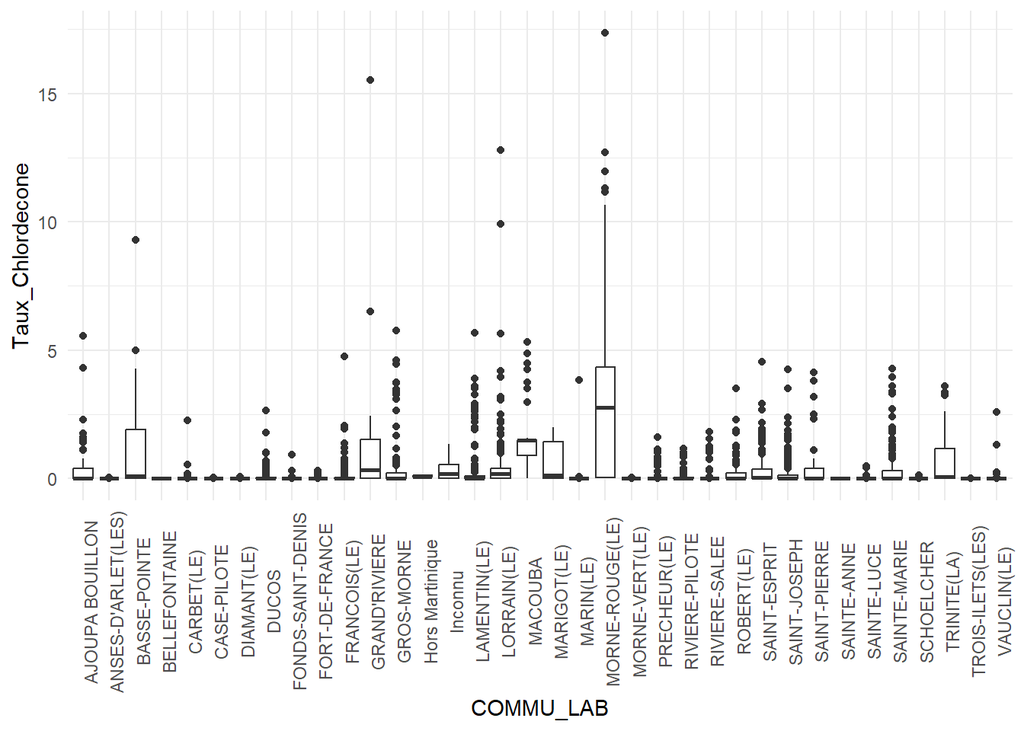

```r
ggplot(data, aes(x = COMMU_LAB, y = Taux_Chlordecone)) +
  geom_boxplot() +
  theme_minimal() +
  theme(axis.text.x = element_text(angle = 90))
```

```r
anova_commune <- aov(Taux_Chlordecone ~ COMMU_LAB, data = data)
summary(anova_commune)
```

```
##                Df Sum Sq Mean Sq F value Pr(>F)
## COMMU_LAB      35  22895   654.1   384.9 <2e-16 ***
## Residuals   31090  52841     1.7
## ---
## Signif. codes:  0 '***' 0.001 '**' 0.01 '*' 0.05 '.' 0.1 ' ' 1
```

La p-value confirme encore une fois que la variable a une influence sur la variable à expliquer.

## Corrélations avec les variables topographiques

```r
vars_topo <- data[, c("Taux_Chlordecone",
                      "mnt_pente_mean",
                      "mnt_exposition_mean",
                      "mnt_ombrage_mean",
                      "mnt_rugosite_mean",
                      "mnt_tri_mean",
                      "mnt_tpi_mean")]

cor_matrix <- cor(vars_topo, use = "complete.obs")

cor_df <- as.data.frame(as.table(cor_matrix))
colnames(cor_df) <- c("Var1", "Var2", "Correlation")
```

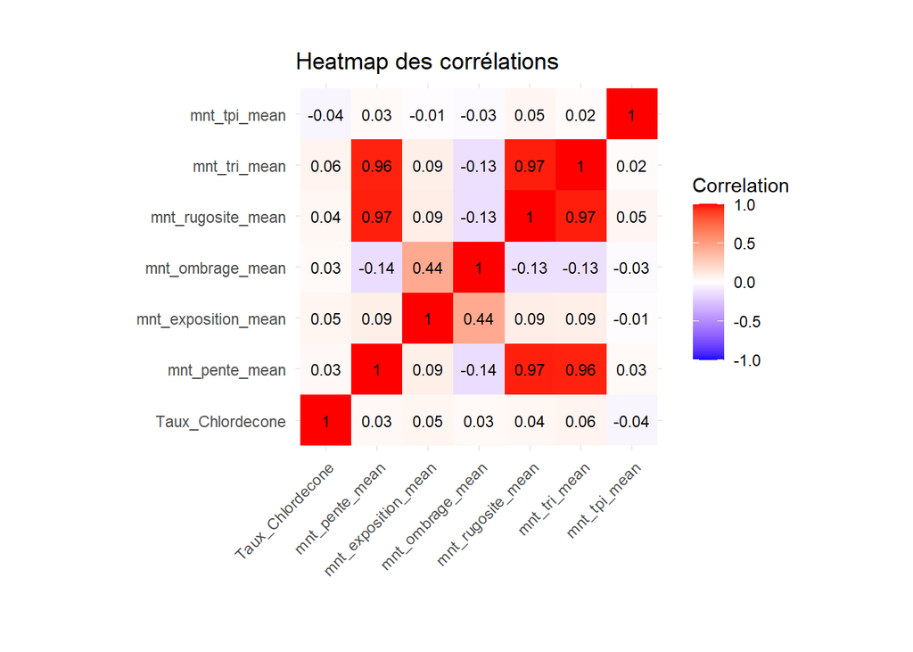

```r
ggplot(cor_df, aes(x = Var1, y = Var2, fill = Correlation)) +
  geom_tile() +
  geom_text(aes(label = round(Correlation, 2)), size = 3) +
  scale_fill_gradient2(low = "blue", high = "red", mid = "white",
                       midpoint = 0, limits = c(-1, 1)) +
  theme_minimal() +
  theme(
    axis.text.x = element_text(angle = 45, hjust = 1),
    plot.margin = unit(c(1, 1, 1, 1), "cm")
  ) +
  coord_fixed() +
  labs(title = "Heatmap des corrélations",
       x = "",
       y = "")
```

Les variables mises en avant sont très peu corrélées au taux de chlordécone.

## Effet du temps (année)

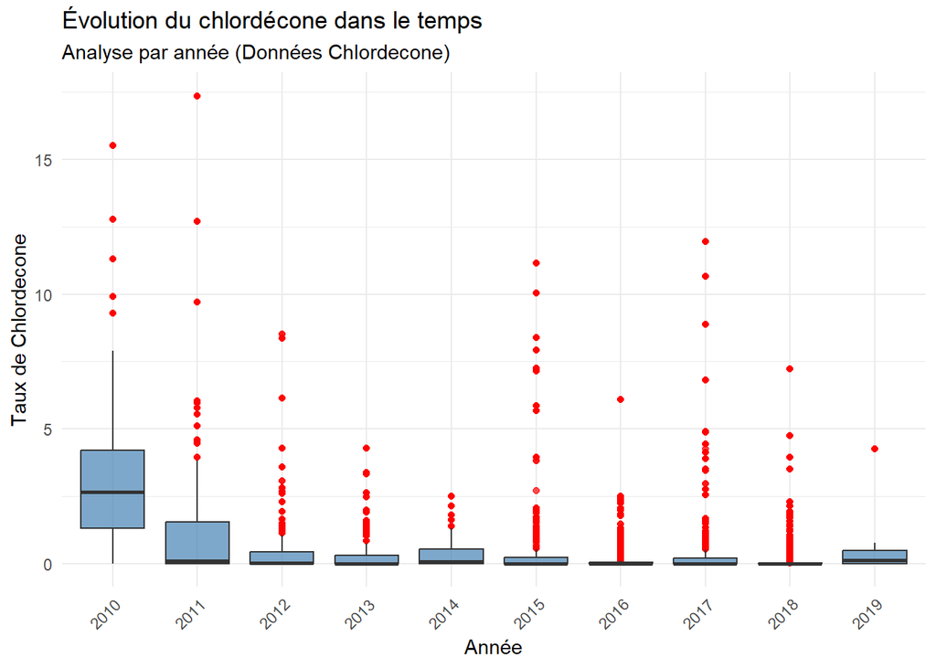

```r
ggplot(data, aes(x = as.factor(ANNEE), y = Taux_Chlordecone)) +
  geom_boxplot(fill = "steelblue", outlier.color = "red", alpha = 0.7) +
  theme_minimal() +
  labs(
    title = "Évolution du chlordécone dans le temps",
    subtitle = "Analyse par année (Données Chlordecone)",
    x = "Année",
    y = "Taux de Chlordecone"
  ) +
  theme(axis.text.x = element_text(angle = 45, hjust = 1))
```

```r
model_time <- lm(Taux_Chlordecone ~ ANNEE, data = data)
summary(model_time)
```

```
##
## Call:
## lm(formula = Taux_Chlordecone ~ ANNEE, data = data)
##
## Residuals:
##     Min      1Q  Median      3Q     Max
## -1.9822 -0.4979 -0.1927  0.0102 15.6123
##
## Coefficients:
##               Estimate Std. Error t value Pr(>|t|)
## (Intercept) 499.976907   5.658782   88.35   <2e-16 ***
## ANNEE        -0.247757   0.002808  -88.24   <2e-16 ***
## ---
## Signif. codes:  0 '***' 0.001 '**' 0.01 '*' 0.05 '.' 0.1 ' ' 1
##
## Residual standard error: 1.395 on 31124 degrees of freedom
## Multiple R-squared:  0.2001, Adjusted R-squared:  0.2001
## F-statistic:  7786 on 1 and 31124 DF,  p-value: < 2.2e-16
```

Visiblement la Taux semble baisser avec le temps, cette évolution est observable sur le graphique avec la médiane des box plot, les boîtes sont de plus en plus petites (homogénéisation des taux). Certaines années la présence d’outiers est très important ce qui pourrait s’expliquer par différentes variables (déréglement climatique par exemple).

## Lien entre chlordecone et 5b-hydro

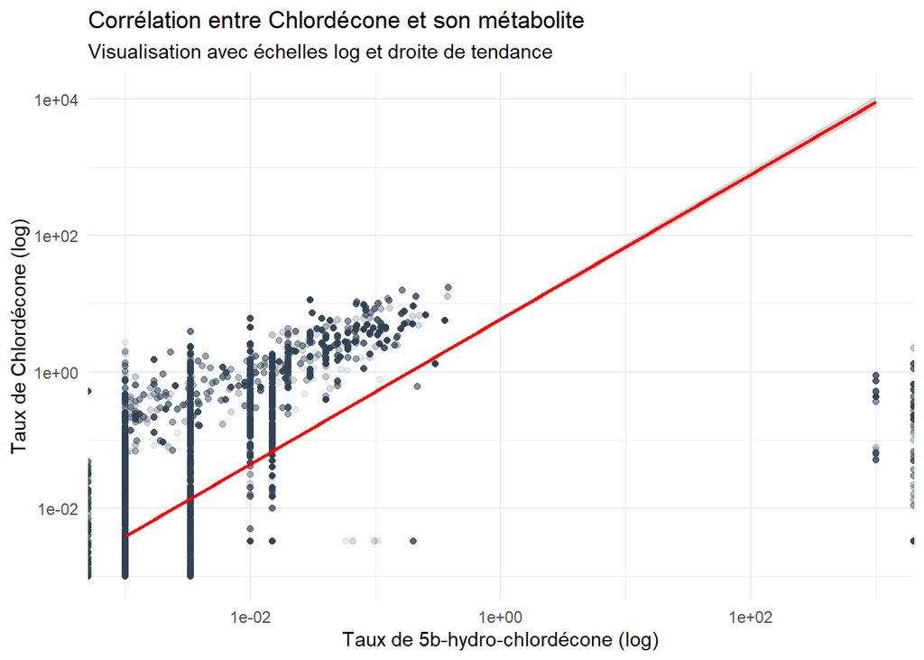

```r
ggplot(data, aes(x = Taux_5b_hydro, y = Taux_Chlordecone)) +
  # alpha = 0.1 rend les points transparents : les zones sombres sont les plus denses
  geom_point(alpha = 0.1, color = "#2c3e50") +
  # Ajout d'une droite de régression linéaire (méthode lm)
  geom_smooth(method = "lm", color = "red", se = TRUE) +
  # Passage en échelle logarithmique (très utile pour les polluants)
  scale_x_log10() +
  scale_y_log10() +
  theme_minimal() +
  labs(
    title = "Corrélation entre Chlordécone et son métabolite",
    subtitle = "Visualisation avec échelles log et droite de tendance",
    x = "Taux de 5b-hydro-chlordécone (log)",
    y = "Taux de Chlordécone (log)"
  )
```

Dans la recherche de corrélation entre les deux variables, on observe que les valeurs de taux de 5b-hydro sont anormalement distribuées.

Donc on va analyser en profondeur ces données.

```r
# Voir les valeurs uniques présentes
unique(data$Taux_5b_hydro)
```

```
##   [1] 7.00e-02      Inf 1.50e-02 2.00e-02 1.00e-02 3.30e-03       NA 5.00e-02
##   [9] 3.00e-02 8.00e-02 3.00e-01 4.00e-02 1.70e-02 1.70e-03 5.20e-02 9.00e-02
##  [17] 6.00e-02 1.17e-01 2.40e-02 3.70e-02 1.24e-01 9.60e-02 1.60e-01 1.20e-01
##  [25] 1.10e-01 3.56e-01 1.80e-01 1.70e-01 4.30e-02 1.03e-01 2.50e-01 1.61e-01
##  [33] 8.30e-02 9.90e-02 2.10e-01 1.28e-01 1.05e-01 2.30e-02 4.70e-02 2.50e-02
##  [41] 3.80e-02 1.90e-02 1.00e-03 1.08e-01 1.80e-02 1.25e-01 8.40e-02 7.10e-02
##  [49] 1.07e-01 4.60e-02 8.60e-02 1.11e-02 3.50e-03 2.93e-02 1.79e-02 1.23e-03
##  [57] 5.30e-03 1.10e-03 1.40e-03 5.90e-03 3.90e-03 1.80e-03 6.80e-03 3.20e-03
##  [65] 2.20e-02 6.30e-03 6.40e-03 9.99e+02 2.50e-03 1.31e-02 0.00e+00 1.20e-03
##  [73] 3.80e-03 3.40e-02 5.80e-02 1.04e-01 6.60e-02 2.70e-02 1.20e-02 2.80e-02
##  [81] 1.09e-01 5.90e-02 5.30e-02 2.60e-02 3.20e-02 1.30e-02 7.60e-02 1.10e-02
##  [89] 3.50e-02 3.30e-02 5.10e-02 6.80e-02 2.10e-02 5.70e-02 1.00e-01 1.50e-01
##  [97] 3.10e-02 1.48e-01 6.40e-02 2.20e-01 1.97e-01 2.24e-01 9.10e-02 1.30e-01
## [105] 2.00e-01 3.74e-01 3.80e-01 2.90e-02 4.30e-03 1.50e-03 1.60e-03 9.00e-03
## [113] 1.60e-02 8.00e-03 6.00e-03 3.18e-02 1.28e-02 2.40e-03 4.60e-03 1.03e-03
## [121] 3.00e-03 4.57e-02 1.02e-02 2.66e-02 1.04e-02 3.38e-02 6.60e-03 3.96e-02
## [129] 1.67e-02 1.90e-03 4.80e-03 1.14e-02 9.70e-03 1.08e-02 9.80e-03 4.50e-03
## [137] 9.40e-03 2.00e-03 7.00e-03 2.30e-03 4.40e-03 2.10e-03 1.30e-03 2.05e-02
## [145] 2.90e-03 2.60e-03 3.70e-03 4.10e-03 2.15e-01 1.42e-01 1.64e-01 2.20e-03
## [153] 3.13e-02 5.00e-03 3.40e-03
```

```r
# Compter l'occurrence de chaque valeur
table(data$Taux_5b_hydro)
```

```
##
##       0   0.001 0.00103  0.0011  0.0012 0.00123  0.0013  0.0014  0.0015  0.0016
##    1336    8444       2      42      94       7      36      18       5       8
##  0.0017  0.0018  0.0019   0.002  0.0021  0.0022  0.0023  0.0024  0.0025  0.0026
##      89      17      23      33      40      15      10      14      24      10
##  0.0029   0.003  0.0032  0.0033  0.0034  0.0035  0.0037  0.0038  0.0039  0.0041
##       8       7      17    5867       2      13      10      47      23       5
##  0.0043  0.0044  0.0045  0.0046  0.0048   0.005  0.0053  0.0059   0.006  0.0063
##       7       6       6       6      13       7       8       7      36      16
##  0.0064  0.0066  0.0068   0.007   0.008   0.009  0.0094  0.0097  0.0098    0.01
##      20       7       4      26      18      45       5       2       2    3433
##  0.0102  0.0104  0.0108   0.011  0.0111  0.0114   0.012  0.0128   0.013  0.0131
##       9       5       4      14      13       6      55       6       9       8
##   0.015   0.016  0.0167   0.017  0.0179   0.018   0.019    0.02  0.0205   0.021
##    5375       5       1      29       1      35      48     469       8       7
##   0.022   0.023   0.024   0.025   0.026  0.0266   0.027   0.028   0.029  0.0293
##      20      43       6       8      11       5       1       4       3       2
##    0.03   0.031  0.0313  0.0318   0.032   0.033  0.0338   0.034   0.035   0.037
##     484      28       1       1       1       3       2      20       4      97
##   0.038  0.0396    0.04   0.043  0.0457   0.046   0.047    0.05   0.051   0.052
##      44      11     563      61       3      64      14     127       4      56
##   0.053   0.057   0.058   0.059    0.06   0.064   0.066   0.068    0.07   0.071
##       1      60       1       1     236       5       2      32     104      38
##   0.076    0.08   0.083   0.084   0.086    0.09   0.091   0.096   0.099     0.1
##       1     222      36      12     110     142       8     156      14       3
##   0.103   0.104   0.105   0.107   0.108   0.109    0.11   0.117    0.12   0.124
##     138       1      12      44      58       1     183      18      67     372
##   0.125   0.128    0.13   0.142   0.148    0.15    0.16   0.161   0.164    0.17
##       6      11       2      12      10      12      29      20       9      63
##    0.18   0.197     0.2    0.21   0.215    0.22   0.224    0.25     0.3   0.356
##       9      52      51      14       8       2       2     122      76      40
##   0.374    0.38     999     Inf
##       3      10     138     586
```

L’analyse de ces résultats montre que la variable n’est pas “plate” (elle contient beaucoup de valeurs différentes), mais elle contient des valeurs critiques qui empêchent tout calcul statistique

```r
# Création d'un dataset filtré
# On enlève les Infini, les NA, et la valeur aberrante 999
data_propre <- subset(data,
                      is.finite(Taux_5b_hydro) &
                      is.finite(Taux_Chlordecone) &
                      Taux_5b_hydro < 900) # Exclut le code 999

# Calcul de la corrélation sur les données nettoyées
# On utilise Spearman car vos données ont des seuils de détection (0.001, 0.0033...)
res_cor <- cor(data_propre$Taux_5b_hydro,
               data_propre$Taux_Chlordecone,
               method = "spearman")

print(res_cor)
```

```
## [1] 0.646169
```

Après nettoyage des données (exclusion des valeurs infinies et des codes erreurs 999), le coefficient de corrélation de Spearman s’élève à $0,646$. Ce résultat démontre une liaison statistique robuste et positive entre le polluant et son produit de dégradation, confirmant la pertinence du 5b-hydro-chlordécone comme indicateur de suivi environnemental.

## Régression linéaire multiple

On decide d’introduire toutes les variables significatives dans un seul modèle.

```r
model <- lm(Taux_Chlordecone ~ Sol_simple +
                                  RAIN +
                                  ANNEE,
            data = data)

summary(model)
```

```
##
## Call:
## lm(formula = Taux_Chlordecone ~ Sol_simple + RAIN + ANNEE, data = data)
##
## Residuals:
##     Min      1Q  Median      3Q     Max
## -2.5084 -0.6165 -0.1237  0.3148 15.4119
##
## Coefficients:
##                        Estimate Std. Error t value Pr(>|t|)
## (Intercept)          441.628622   5.634115  78.385  < 2e-16 ***
## Sol_simpleAndosol      0.519001   0.038553  13.462  < 2e-16 ***
## Sol_simpleFerralsol    0.055684   0.038791   1.435  0.15116
## Sol_simpleInconnu      0.372481   0.159684   2.333  0.01967 *
## Sol_simpleNitisol     -0.090607   0.042863  -2.114  0.03454 *
## Sol_simpleNo data      0.511562   0.043905  11.652  < 2e-16 ***
## Sol_simpleUrban area   0.200303   0.061097   3.278  0.00105 **
## Sol_simpleVertisol     0.043379   0.037372   1.161  0.24576
## RAIN1250-1500          0.217809   0.084344   2.582  0.00982 **
## RAIN1500-2000          0.398612   0.078355   5.087 3.65e-07 ***
## RAIN2000-3000          0.652639   0.076926   8.484  < 2e-16 ***
## RAIN3000-5000          1.007016   0.079350  12.691  < 2e-16 ***
## RAIN5000-8000         -0.403669   0.159354  -2.533  0.01131 *
## ANNEE                 -0.219225   0.002795 -78.431  < 2e-16 ***
## ---
## Signif. codes:  0 '***' 0.001 '**' 0.01 '*' 0.05 '.' 0.1 ' ' 1
##
## Residual standard error: 1.34 on 31112 degrees of freedom
## Multiple R-squared:  0.2621, Adjusted R-squared:  0.2618
## F-statistic: 850.2 on 13 and 31112 DF,  p-value: < 2.2e-16
```

Le modèle de régression est globalement significatif (p-value < 0.001), ce qui indique que les variables explicatives incluses dans le modèle expliquent une partie significative de la variabilité du taux de chlordécone. Le coefficient de détermination R² = 0.262 indique que le modèle explique environ 26 % de la variabilité du taux de chlordécone. Cela signifie que d’autres facteurs non inclus dans le modèle influencent également la contamination.

Plus précisément, voici les analyses pour chaque variables et pour chaque modalité :

- L’année a un effet négatif et significatif sur le taux de chlordécone. Cela signifie que la contamination diminue au fil du temps. Cette diminution peut s’expliquer par la dégradation progressive du chlordécone dans les sols et par l’arrêt de son utilisation.
- Le type de sol influence significativement la contamination au chlordécone. Les sols de type Andosol présentent des niveaux de contamination plus élevés, tandis que les sols de type Nitisol présentent des niveaux plus faibles. Cela suggère que certaines propriétés des sols, comme la capacité de rétention ou la composition minérale, influencent la persistance du chlordécone dans l’environnement.
- La pluviométrie influence significativement la contamination au chlordécone. Une augmentation de la pluviométrie est associée à une augmentation du taux de chlordécone jusqu’à un certain seuil, probablement en raison du lessivage des sols et du transport du pesticide. En revanche, dans les zones de très forte pluviométrie, la contamination diminue, ce qui peut s’expliquer par un lessivage plus important entraînant une dilution du pesticide.

## Autre modélisation : Random Forest

```r
rf <- randomForest(Taux_Chlordecone ~ Sol_simple +
                                          RAIN +
                                          mnt_pente_mean +
                                          mnt_exposition_mean +
                                          mnt_ombrage_mean +
                                          mnt_rugosite_mean +
                                          mnt_tri_mean +
                                          mnt_tpi_mean +
                                          ANNEE,
                   data = data,
                   importance = TRUE)

importance(rf)
```

```
##                       %IncMSE IncNodePurity
## Sol_simple           71.88846      4646.014
## RAIN                 60.52296      3482.828
## mnt_pente_mean       54.78577      6281.387
## mnt_exposition_mean  93.85167      8087.858
## mnt_ombrage_mean     69.47349      6903.438
## mnt_rugosite_mean    52.57086      6623.145
## mnt_tri_mean         61.44300      6943.142
## mnt_tpi_mean         70.33284      6083.264
## ANNEE               233.35662     23390.901
```

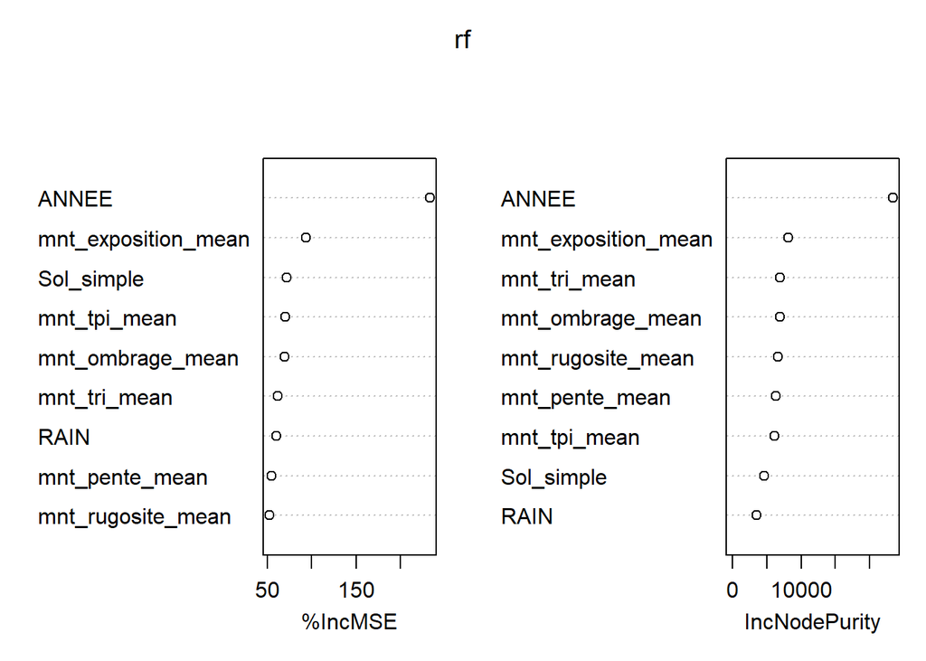

```r
varImpPlot(rf)
```

On a deux indicateurs important ici sur l’importance des variables :

- %IncMSE → importance pour la prédiction (le plus important)
- IncNodePurity → importance dans les arbres (moins interprétable)

Le modèle Random Forest met en évidence que la variable la plus importante dans l’explication de la contamination au chlordécone est l’année, ce qui confirme une évolution temporelle de la contamination. Les variables topographiques, notamment l’exposition et l’ombrage, apparaissent également comme des facteurs déterminants. La pluviométrie et le type de sol jouent également un rôle important. Ces résultats montrent que la contamination dépend à la fois de facteurs temporels, climatiques, pédologiques et topographiques.

La contamination au chlordécone est principalement expliquée par des facteurs temporels, mais également par des facteurs environnementaux tels que l’exposition, l’ombrage, la pluviométrie, le type de sol et la topographie, qui influencent la rétention et le transport du pesticide dans les sols.

# Y a-t-il des zones géographiques plus contaminées que d’autres ? (Cartographie)

```r
# Transformer en objet spatial
data_sf <- st_as_sf(data,
                    coords = c("X", "Y"),
                    crs = 2972)  # à adapter si tes coordonnées sont en Lambert Antilles
```

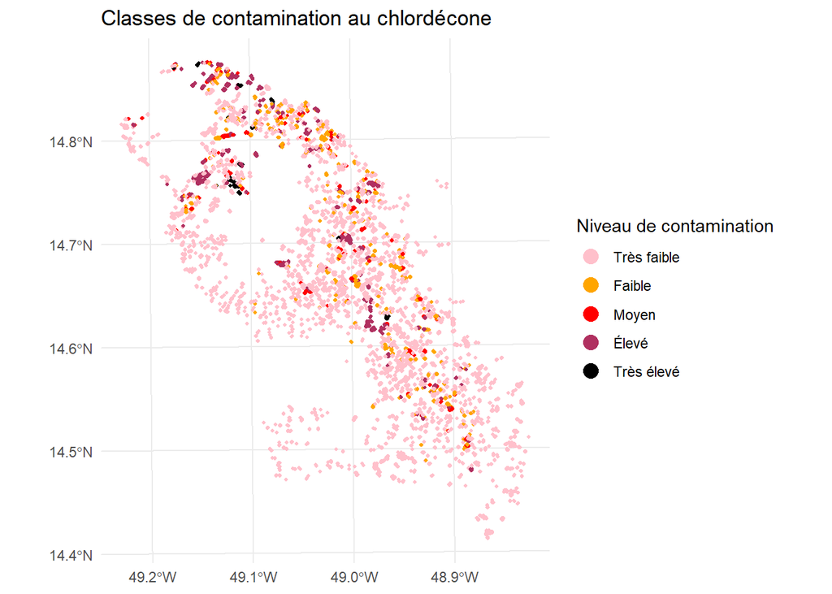

```r
data$classe_contamination <- cut(data$Taux_Chlordecone,
                                 breaks = c(0, 0.1, 0.5, 1, 5, max(data$Taux_Chlordecone)),
                                 labels = c("Très faible", "Faible", "Moyen", "Élevé", "Très élevé"))

data_sf <- st_as_sf(data, coords = c("X", "Y"), crs = 2972)

ggplot(data_sf) +
  geom_sf(aes(color = classe_contamination), size = 0.7) +
  theme_minimal() +
  labs(title = "Classes de contamination au chlordécone",
       color = "Niveau de contamination") +
  scale_color_manual(values = c("pink", "orange", "red", "maroon", "black")) +
  guides(color = guide_legend(override.aes = list(size = 4)))
```

La cartographie des classes de contamination met en évidence une hétérogénéité spatiale de la pollution au chlordécone. Certaines zones présentent des niveaux de contamination plus élevés, ce qui suggère l’influence de facteurs environnementaux et historiques. Cette cartographie permet d’identifier visuellement les zones prioritaires pour la surveillance et la gestion du risque sanitaire.

```r
contamination_commune <- data %>%
  group_by(COMMU_LAB) %>%
  summarise(
    moyenne_chlordecone = mean(Taux_Chlordecone, na.rm = TRUE),
    nb_parcelles = n()
  )
```

```r
contamination_commune %>%
  arrange(desc(moyenne_chlordecone))
```

```
## # A tibble: 36 × 3
##    COMMU_LAB       moyenne_chlordecone nb_parcelles
##    <chr>                         <dbl>        <int>
##  1 MORNE-ROUGE(LE)               2.80          3725
##  2 GRAND'RIVIERE                 1.84           125
##  3 MACOUBA                       1.70           698
##  4 BASSE-POINTE                  1.38           992
##  5 TRINITE(LA)                   0.684         1101
##  6 MARIGOT(LE)                   0.613          475
##  7 LORRAIN(LE)                   0.584         1763
##  8 SAINT-PIERRE                  0.561          339
##  9 GROS-MORNE                    0.547         2093
## 10 LAMENTIN(LE)                  0.442         1930
## # ℹ 26 more rows
```

On va maintenant approfondir l’analyse spatial.

```r
# Chargement du shapefile de la Martinique (package cartography)
martinique_sf <- st_read(dsn = system.file("gpkg/mtq.gpkg",
                                            package = "cartography"),
                         quiet = TRUE)

# Aperçu des colonnes disponibles
head(martinique_sf)
```

```
## Simple feature collection with 6 features and 7 fields
## Geometry type: MULTIPOLYGON
## Dimension:     XY
## Bounding box:  xmin: 695444 ymin: 1598818 xmax: 717731 ymax: 1645182
## Projected CRS: WGS 84 / UTM zone 20N
##   INSEE_COM              STATUS            LIBGEO  POP   MED CHOM  ACT
## 1     97201 Simple municipality L'Ajoupa-Bouillon 1902 13633  254  801
## 2     97202 Simple municipality Les Anses-d'Arlet 3737 14558  425 1659
## 3     97203 Simple municipality      Basse-Pointe 3357 14456  400 1395
## 4     97204 Simple municipality         Le Carbet 3683 18847  285 1568
## 5     97205 Simple municipality       Case-Pilote 4458 21005  347 2096
## 6     97206 Simple municipality        Le Diamant 5976 19704  430 2654
##                             geom
## 1 MULTIPOLYGON (((699261 1637...
## 2 MULTIPOLYGON (((709840 1599...
## 3 MULTIPOLYGON (((697602 1638...
## 4 MULTIPOLYGON (((702229 1628...
## 5 MULTIPOLYGON (((698805 1621...
## 6 MULTIPOLYGON (((709840 1599...
```

```r
st_crs(martinique_sf)
```

[output not shown]

## Préparation : agrégation des données par commune

```r
# ---- Nettoyage des noms de communes ----------------------------------------
# La variable COMMU_LAB contient des noms en majuscules avec articles en fin
# (ex : "MORNE-ROUGE(LE)"). On crée une version normalisée pour la jointure.

normaliser_commune <- function(x) {
  x <- toupper(x)
  x <- trimws(x)
  # Supprimer les accents
  x <- iconv(x, to = "ASCII//TRANSLIT")
  # Supprimer articles entre parenthèses
  x <- gsub("\\(LE\\)|\\(LA\\)|\\(LES\\)|\\(L'\\)", "", x)
  # Supprimer caractères spéciaux résiduels
  x <- gsub("[^A-Z0-9' -]", "", x)
  x <- trimws(x)
  return(x)
}

# Normalisation du shapefile
martinique_sf <- martinique_sf %>%
  mutate(LIBGEO_NORM = normaliser_commune(LIBGEO))

# Normalisation dans les données
data <- data %>%
  mutate(COMMU_NORM = normaliser_commune(COMMU_LAB))

# Vérification du mapping (détecter les communes non appariées)
communes_data   <- sort(unique(data$COMMU_NORM))
communes_shp    <- sort(unique(martinique_sf$LIBGEO_NORM))
cat("Communes présentes dans les données mais absentes du shapefile :\n")
```

```
## Communes présentes dans les données mais absentes du shapefile :
```

```r
print(setdiff(communes_data, communes_shp))
```

```
##  [1] "AJOUPA BOUILLON" "ANSES-D'ARLET"   "CARBET"          "DIAMANT"
##  [5] "FRANCOIS"        "HORS MARTINIQUE" "INCONNU"         "LAMENTIN"
##  [9] "LORRAIN"         "MARIGOT"         "MARIN"           "MORNE-ROUGE"
## [13] "MORNE-VERT"      "PRECHEUR"        "ROBERT"          "TRINITE"
## [17] "TROIS-ILETS"     "VAUCLIN"
```

```r
# Corrections manuelles si nécessaire après vérification ci-dessus
data <- data %>%
  mutate(COMMU_NORM = case_when(
    COMMU_NORM == "FRANCOIS"          ~ "LE FRANCOIS",
    COMMU_NORM == "DIAMANT"           ~ "LE DIAMANT",
    COMMU_NORM == "LORRAIN"           ~ "LE LORRAIN",
    COMMU_NORM == "ROBERT"            ~ "LE ROBERT",
    COMMU_NORM == "VAUCLIN"           ~ "LE VAUCLIN",
    COMMU_NORM == "MARIN"             ~ "LE MARIN",
    COMMU_NORM == "CARBET"            ~ "LE CARBET",
    COMMU_NORM == "LAMENTIN"          ~ "LE LAMENTIN",
    COMMU_NORM == "MARIGOT"           ~ "LE MARIGOT",
    COMMU_NORM == "PRECHEUR"          ~ "LE PRECHEUR",
    COMMU_NORM == "MORNE-ROUGE"       ~ "LE MORNE-ROUGE",
    COMMU_NORM == "MORNE-VERT"        ~ "LE MORNE-VERT",
    COMMU_NORM == "TRINITE"           ~ "LA TRINITE",
    COMMU_NORM == "ANSES-D'ARLET"     ~ "LES ANSES-D'ARLET",
    COMMU_NORM == "TROIS-ILETS"       ~ "LES TROIS-ILETS",
    COMMU_NORM == "GRAND'RIVIERE"     ~ "GRAND-RIVIERE",
    TRUE ~ COMMU_NORM
  ))
```

```r
# Agrégation des indicateurs clés par commune
stats_communes <- data %>%
  filter(COMMU_NORM != normaliser_commune("Hors Martinique")) %>%
  group_by(COMMU_NORM) %>%
  summarise(
    moy_chlordecone    = mean(Taux_Chlordecone, na.rm = TRUE),
    med_chlordecone    = median(Taux_Chlordecone, na.rm = TRUE),
    max_chlordecone    = max(Taux_Chlordecone, na.rm = TRUE),
    nb_prelevements    = n(),
    pct_contaminees    = mean(Taux_Chlordecone > 0.1, na.rm = TRUE) * 100,
    pct_fortement_cont = mean(Taux_Chlordecone > 1.0, na.rm = TRUE) * 100,
    .groups = "drop"
  )

# Jointure avec le shapefile
martinique_stats_sf <- martinique_sf %>%
  left_join(stats_communes, by = c("LIBGEO_NORM" = "COMMU_NORM"))

head(martinique_stats_sf)
```

```
## Simple feature collection with 6 features and 14 fields
## Geometry type: MULTIPOLYGON
## Dimension:     XY
## Bounding box:  xmin: 695444 ymin: 1598818 xmax: 717731 ymax: 1645182
## Projected CRS: WGS 84 / UTM zone 20N
##   INSEE_COM              STATUS            LIBGEO  POP   MED CHOM  ACT
## 1     97201 Simple municipality L'Ajoupa-Bouillon 1902 13633  254  801
## 2     97202 Simple municipality Les Anses-d'Arlet 3737 14558  425 1659
## 3     97203 Simple municipality      Basse-Pointe 3357 14456  400 1395
## 4     97204 Simple municipality         Le Carbet 3683 18847  285 1568
## 5     97205 Simple municipality       Case-Pilote 4458 21005  347 2096
## 6     97206 Simple municipality        Le Diamant 5976 19704  430 2654
##         LIBGEO_NORM moy_chlordecone med_chlordecone max_chlordecone
## 1 L'AJOUPA-BOUILLON              NA              NA              NA
## 2 LES ANSES-D'ARLET     0.007658091          0.0010          0.0510
```

[output cut: 18 more lines]

## Carte 1 : Taux moyen de chlordécone par commune

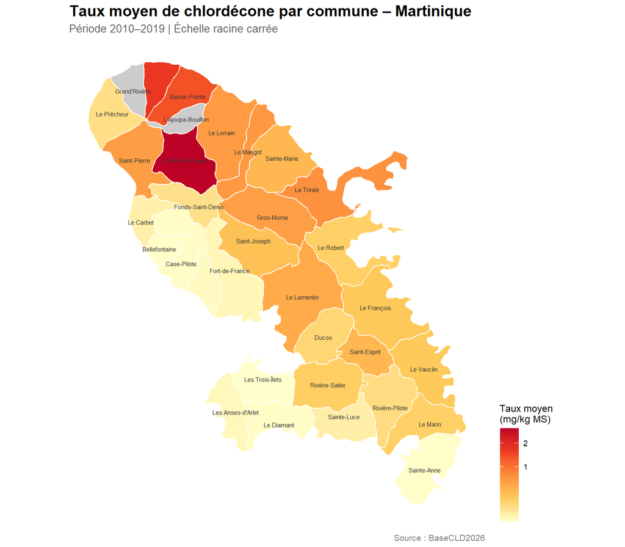

```r
ggplot(martinique_stats_sf) +
  geom_sf(aes(fill = moy_chlordecone), color = "white", linewidth = 0.4) +
  scale_fill_gradientn(
    colours  = c("#ffffcc", "#fecc5c", "#fd8d3c", "#f03b20", "#bd0026"),
    name     = "Taux moyen\n(mg/kg MS)",
    na.value = "grey80",
    trans    = "sqrt"        # racine carrée pour mieux lire les faibles valeurs
  ) +
  geom_sf_text(aes(label = LIBGEO), size = 2, color = "grey20", check_overlap = TRUE) +
  theme_map() +
  theme(
    legend.position   = "right",
    plot.title        = element_text(size = 14, face = "bold"),
    plot.subtitle     = element_text(size = 10, color = "grey40"),
    plot.caption      = element_text(size = 8,  color = "grey50")
  ) +
  labs(
    title    = "Taux moyen de chlordécone par commune – Martinique",
    subtitle = "Période 2010–2019 | Échelle racine carrée",
    caption  = "Source : BaseCLD2026"
  )
```

## Carte 2 : Pourcentage de parcelles dépassant le seuil réglementaire (0,1 mg/kg)

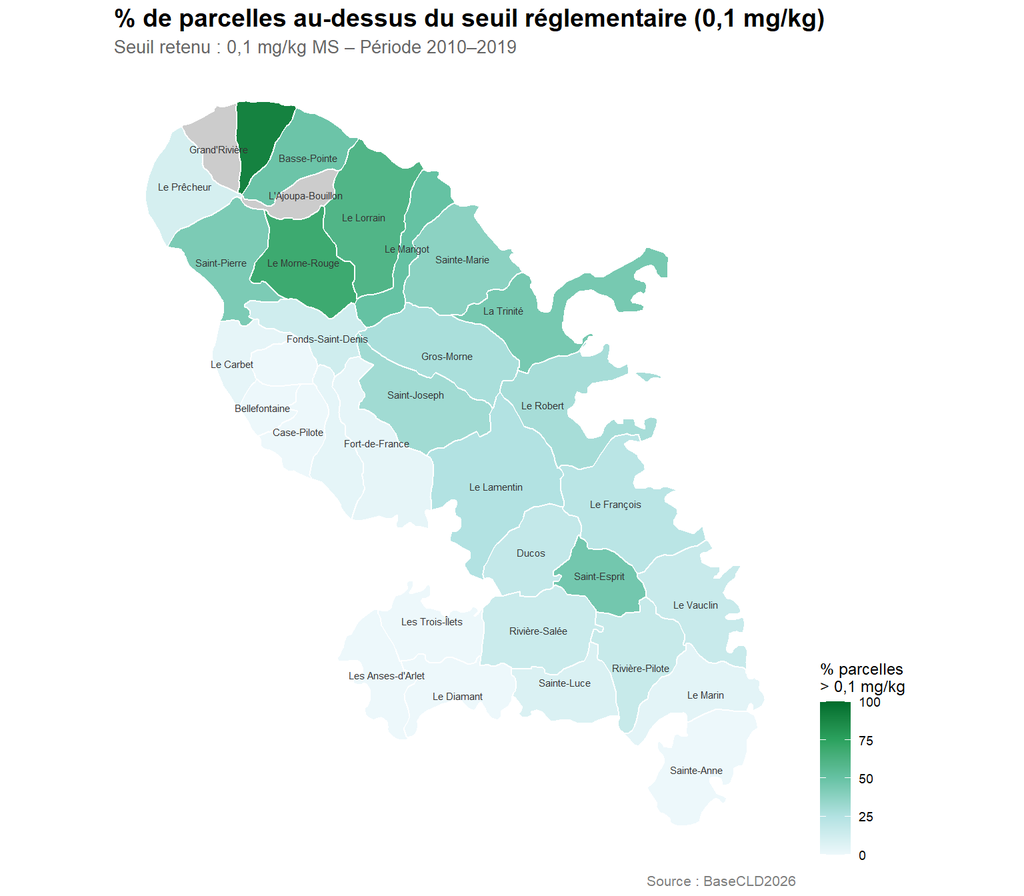

```r
ggplot(martinique_stats_sf) +
  geom_sf(aes(fill = pct_contaminees), color = "white", linewidth = 0.4) +
  scale_fill_gradientn(
    colours  = c("#edf8fb", "#b2e2e2", "#66c2a4", "#2ca25f", "#006d2c"),
    name     = "% parcelles\n> 0,1 mg/kg",
    na.value = "grey80",
    limits   = c(0, 100)
  ) +
  geom_sf_text(aes(label = LIBGEO), size = 2, color = "grey20", check_overlap = TRUE) +
  theme_map() +
  theme(
    legend.position = "right",
    plot.title      = element_text(size = 14, face = "bold"),
    plot.subtitle   = element_text(size = 10, color = "grey40"),
    plot.caption    = element_text(size = 8,  color = "grey50")
  ) +
  labs(
    title    = "% de parcelles au-dessus du seuil réglementaire (0,1 mg/kg)",
    subtitle = "Seuil retenu : 0,1 mg/kg MS – Période 2010–2019",
    caption  = "Source : BaseCLD2026"
  )
```

La part de parcelles dépassant le seuil réglementaire (0,1 mg/kg MS) confirme ce gradient géographique et souligne que dans certaines communes plus de 80 % des parcelles sont concernées.

## Carte 3 : Évolution temporelle — comparaison 2010 vs 2019

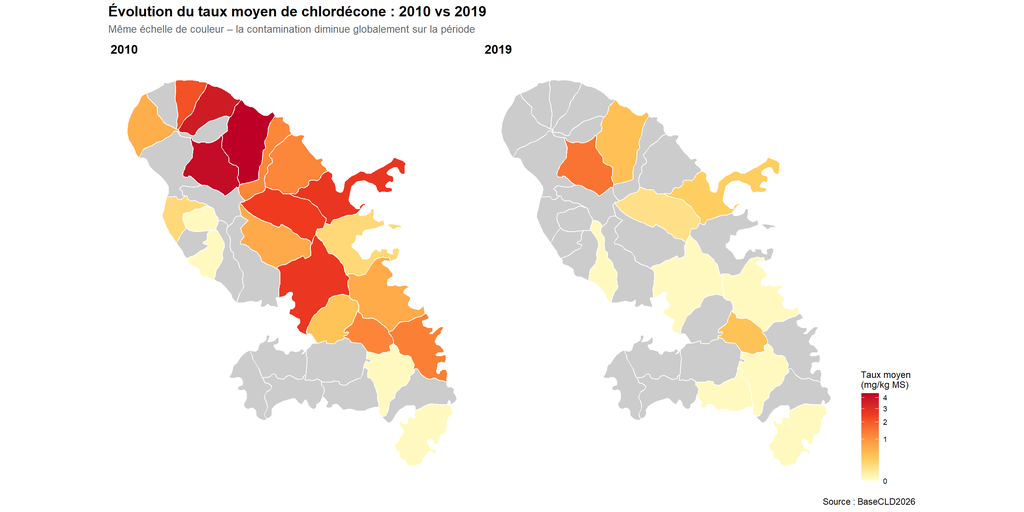

```r
# Statistiques par commune pour 2010 et 2019
stats_2010 <- data %>%
  filter(ANNEE == 2010,
         COMMU_NORM != normaliser_commune("Hors Martinique")) %>%
  group_by(COMMU_NORM) %>%
  summarise(moy_chld = mean(Taux_Chlordecone, na.rm = TRUE), .groups = "drop")

stats_2019 <- data %>%
  filter(ANNEE == 2019,
         COMMU_NORM != normaliser_commune("Hors Martinique")) %>%
  group_by(COMMU_NORM) %>%
  summarise(moy_chld = mean(Taux_Chlordecone, na.rm = TRUE), .groups = "drop")

shp_2010 <- martinique_sf %>% left_join(stats_2010, by = c("LIBGEO_NORM" = "COMMU_NORM"))
shp_2019 <- martinique_sf %>% left_join(stats_2019, by = c("LIBGEO_NORM" = "COMMU_NORM"))

# Échelle commune aux deux cartes
val_max <- max(c(shp_2010$moy_chld, shp_2019$moy_chld), na.rm = TRUE)

palette_grad <- scale_fill_gradientn(
  colours  = c("#ffffcc", "#fecc5c", "#fd8d3c", "#f03b20", "#bd0026"),
  name     = "Taux moyen\n(mg/kg MS)",
  na.value = "grey80",
  limits   = c(0, val_max),
  trans    = "sqrt"
)

p_2010 <- ggplot(shp_2010) +
  geom_sf(aes(fill = moy_chld), color = "white", linewidth = 0.4) +
  palette_grad +
  theme_map() +
  theme(legend.position = "none",
        plot.title = element_text(size = 12, face = "bold")) +
  labs(title = "2010")

p_2019 <- ggplot(shp_2019) +
  geom_sf(aes(fill = moy_chld), color = "white", linewidth = 0.4) +
  palette_grad +
  theme_map() +
  theme(legend.position = "right",
        plot.title = element_text(size = 12, face = "bold")) +
  labs(title = "2019")

(p_2010 | p_2019) +
  plot_annotation(
    title    = "Évolution du taux moyen de chlordécone : 2010 vs 2019",
    subtitle = "Même échelle de couleur – la contamination diminue globalement sur la période",
    caption  = "Source : BaseCLD2026",
    theme    = theme(plot.title    = element_text(size = 14, face = "bold"),
                     plot.subtitle = element_text(size = 10, color = "grey40"))
  )
```

Globalement, avec les années, comme dans les précèdentes analyses, le taux diminu.

## Carte 4 : Nombre de prélèvements par commune (effort d’échantillonnage)

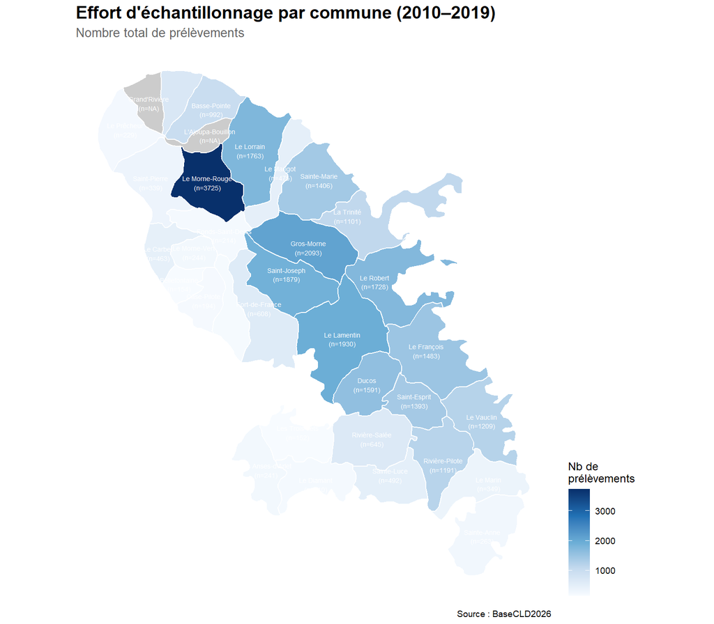

```r
ggplot(martinique_stats_sf) +
  geom_sf(aes(fill = nb_prelevements), color = "white", linewidth = 0.4) +
  scale_fill_gradientn(
    colours  = c("#f7fbff", "#c6dbef", "#6baed6", "#2171b5", "#08306b"),
    name     = "Nb de\nprélèvements",
    na.value = "grey80"
  ) +
  geom_sf_text(aes(label = paste0(LIBGEO, "\n(n=", nb_prelevements, ")")),
               size = 1.8, color = "white", check_overlap = TRUE) +
  theme_map() +
  theme(
    legend.position = "right",
    plot.title      = element_text(size = 14, face = "bold"),
    plot.subtitle   = element_text(size = 10, color = "grey40")
  ) +
  labs(
    title    = "Effort d'échantillonnage par commune (2010–2019)",
    subtitle = "Nombre total de prélèvements",
    caption  = "Source : BaseCLD2026"
  )
```

## Bilan de la section cartographique

La cartographie spatiale confirme et complète les résultats statistiques obtenus dans les sections précédentes :

1. **Hétérogénéité géographique forte** : la contamination n’est pas homogène sur le territoire martiniquais. Les communes du nord et nord-est sont structurellement plus atteintes.
2. **Décroissance temporelle spatialement différenciée** : la baisse du taux moyen observée entre 2010 et 2019 n’est pas uniforme. Certaines communes du nord maintiennent des niveaux élevés.
3. **Zones prioritaires pour la surveillance** : Morne-Rouge, Grand-Rivière, Macouba et Basse-Pointe constituent les foyers de contamination à surveiller en priorité.
4. **Cohérence avec les analyses précédentes** : le type de sol (Andosol, concentré au nord), la pluviométrie et la topographie montagne expliquent en partie cette distribution spatiale.